# *Optimizers in Neural Networks*

## *What are Optimizers?*

*Optimizers are algorithms or methods used to change the attributes of your neural network such as weights and learning rate in order to reduce the losses.*

*At every point in time during training, a neural network has a certain **loss**, or **error**, calculated using a **cost function (also referred to as a loss function)**. This function indicates how ‘wrong’ the network (parameters) is based on the training or validation data. Optimally, the loss would be as low as possible. Unfortunately, cost functions are nonconvex — they don’t just have one minimum, but many, many local minima.*

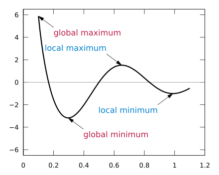

*To minimize a neural network’s loss, an algorithm called **backpropagation** is used. Backpropagation calculates the **derivative of the cost function** with respect to the parameters in the neural network. In other words, it finds the “direction” in which to update the parameters so that the model will perform better. This “direction” is called a neural network’s **gradient**.*

*Before updating the model with the gradient, the **gradient is multiplied by a learning rate**. This yields the actual update on the neural network. When the learning rate is too high, we might step over the minimum, meaning the model is not as good as it could have been.*

*But on the other hand, when the learning rate is too low, the optimization process is extremely slow. Another risk of a low learning rate is the fact that the state might end up in a bad local minimum. The model is at a suboptimal state as this point, but it could be much better.*

*This is where **optimizers** come in. Most optimizers calculate the learning rate automatically. Optimizers also apply the gradient to the neural network — they make the network learn. A good optimizer trains models fast, but it also prevents them from getting stuck in a local minimum.*

## *Gradient Descent*

*Gradient descent is an iterative machine learning optimization algorithm to reduce the cost function. This will help models to make accurate predictions.*

*Gradient indicates the direction of increase. As we want to find the minimum point in the valley we need to go in the opposite direction of the gradient. We update parameters in the negative gradient direction to minimize the loss.*

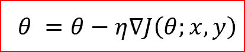

[figure not shown]

*Types of Gradient Descent*

1. *Batch Gradient Descent or Vanilla Gradient Descent*
2. *Stochastic Gradient Descent*
3. *Mini batch Gradient Descent*

### *Learning Rate*

*Learning rate controls how much we should adjust the weights with respect to the loss gradient. Learning rates are randomly initialized.*

- *Lower the value of the learning rate, slower will be the convergence to global minima.*
- *A higher value for learning rate will not allow the gradient descent to converge, the loss function will oscillate or even deviate at the minimum value.*

*Since our goal is to minimize the cost function to find the optimized value for weights, we run multiple iterations with different weights and calculate the cost to arrive at a minimum cost as shown below*

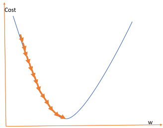

*One measure is to set a **Larger learning rate**. When the change between two iterations is lower than a certain threshold, the learning rate is reduced.*

*However, the setting of this threshold needs to be written in advance adapt to the characteristics of the data set.*

*In addition, this method is to apply the **same learning rate** to all parameter updates. If our data is sparse, we would prefer to update the features with lower frequency.*

*Also, It is possible to have two different bottom for the mountain in the same way we can also get **local or Saddle Point** and **global minimum points** between the cost and weights.*

*Global minima* *is minimum point for the entire domain and **local minima or Saddle Point** is a sub optimal point where we get a relatively minimum point but is not the global minimum point as shown below.*

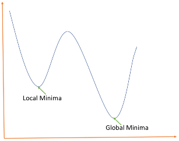

### *Batch Gradient Descent*

*Gradient Update Rule:* *BGD uses the data of the entire training set to calculate the gradient of the cost function to the parameters.*

*Advantages of Batch Gradient Descent*

- *Theoretical analysis of weights and convergence rates are easy to understand*

*Disadvantages of Batch Gradient Descent*

- *Perform redundant computation for the same training example for large datasets*
- *Can be very slow and intractable as large datasets may not fit in the memory*
- *As we take the entire dataset for computation we cannot invest in new data to update the model in real time.*
- *We have to define an iteration number epoch in advance.*
- *This model needs more memory space for train the data.*

*Batch gradient descent can converge to a global minimum for convex functions and to a local minimum for non-convex functions.*

### *SGD (Stochastic Gradient Descent)*

*Gradient Update Rule:* *Compared with BGD's calculation of gradients with all data at one time, SGD updates the gradient of each sample with each update.*

`x += - learning_rate * dx`

*where x is a parameter, dx is the gradient and learning rate is constant*

*we first need to shuffle the dataset so that we get a completely **randomized dataset**. As the dataset is randomized and weights are updated for each single example, update of the weights and the cost function will be noisy jumping all over the place as shown below:*

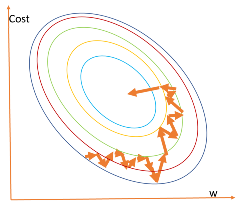

*Random sample helps to arrive at a global minima and avoids getting stuck at a local minima.*

*Learning is much faster and convergence is quick for a very large dataset.*

*Advantages of Stochastic Gradient Descent*

- *Learning is much faster than batch gradient descent*
- *Redundancy is computation is removed as we take one training sample at a time for computation*
- *Weights can be updated on the fly for the new data samples as we take one training sample at a time for computation*

*Disadvantages of Stochastic Gradient Descent*

- *As we frequently update weights, Cost function fluctuates heavily.*

### *Mini-Batch Gradient Descent*

*Gradient Update Rule:* *MBGD is a variation of stochastic gradient descent where instead of single training example, mini-batch of samples is used, that is, n samples to calculate each time. Batch size can vary depending on the dataset. In this way, it can reduce the variance when the parameters are updated, and the convergence is more stable. It can make full use of the highly optimized matrix operations in the deep learning library for more efficient gradient calculations.*

*The difference from SGD is that each cycle does not act on each sample, but a batch with n samples.* **n** *generally value is 50 ～ 256*

*Advantages of Mini-Batch Gradient Descent*

- *Reduces variance of the parameter update and hence lead to stable convergence*
- *Speeds the learning*
- *Does not guarantee good convergence but, helpful to estimate the approximate location of the actual minimum*

*Disadvantages of Mini Batch Gradient Descent*

- *Loss is computed for each mini batch and hence total loss needs to be accumulated across all mini batches.*

## *Momentum*

*One disadvantage of the SGD method is that its update direction depends entirely on the current batch, so its update is very unstable. A simple way to solve this problem is to introduce momentum.*

*Momentum was invented for reducing high variance in SGD and softens the convergence. It accelerates the convergence towards the relevant direction and reduces the fluctuation to the irrelevant direction. One more hyperparameter is used in this method known as momentum symbolized by ‘γ’.*

$$V(t)=γV(t−1)+α.∇J(θ)$$

*Now, the weights are updated by $θ=θ−V(t)$.*

*The momentum term γ is usually set to 0.9 or a similar value.*

*Momentum simulates the inertia of an object when it is moving, that is, the **direction of the previous update is retained to a certain extent during the update, while the current update gradient is used to fine-tune the final update direction**. In this way, you can increase the stability to a certain extent, so that you can learn faster, and also have the ability to get rid of local optimization.*

*Advantages*

- *Reduces the oscillations and high variance of the parameters*
- *Converges faster than gradient descent*

*Disadvantages*

- *One more hyper-parameter is added which needs to be selected manually and accurately.*

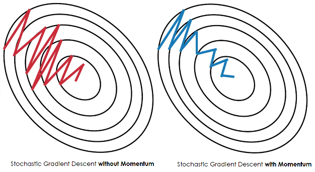

## *Nesterov Accelerated Gradient*

*Momentum may be a good method but if the momentum is too high the algorithm may miss the local minima and may continue to rise up. So, to resolve this issue the NAG algorithm was developed. It is a look ahead method. We know we’ll be using γV(t−1) for modifying the weights so, θ−γV(t−1) approximately tells us the future location. Now, we’ll calculate the cost based on this future parameter rather than the current one.*

$$V(t)=γV(t−1)+α. ∇J( θ−γV(t−1) )$$

*and then update the parameters using $θ=θ−V(t)$.*

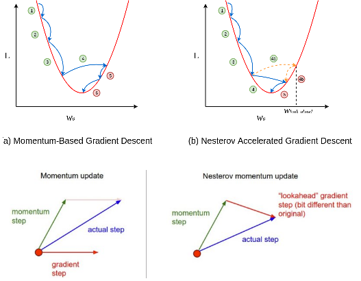

*Advantages*

- *Does not miss the local minima.*
- *Slows if minima’s are occurring.*

*Disadvantages*

- *Still, the hyperparameter needs to be selected manually.*

## *Adagrad - Adaptive Gradient Algorithm*

*Adagrad is an algorithm for gradient-based optimization which adapts the learning rate to the parameters, using **low learning rates for parameters** associated with **frequently occurring features**, and using **high learning rates** for parameters associated with **infrequent features**.*

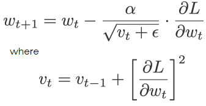

*η is a learning rate which is modified for given parameter θ(i) at a given time based on previous gradients calculated for given parameter θ(i).*

*We store the sum of the squares of the gradients(Gtt) w.r.t. θ(i) up to time step t, while ϵ is a smoothing term that avoids division by zero (usually on the order of 1e−8). Interestingly, without the square root operation, the algorithm performs much worse.*

*So, it is well-suited for dealing with **sparse data**.*

*But the same update rate may not be suitable for all parameters. For example, some parameters may have reached the stage where only fine-tuning is needed, but some parameters need to be adjusted a lot due to the small number of corresponding samples.*

*Adagrad proposed this problem, an algorithm that **adaptively assigns different learning rates to various parameters** among them. The implication is that for each parameter, as its total distance updated increases, its learning rate also slows.*

*Adagrad eliminates the need to manually tune the learning rate.*

*Advantages*

- *Learning rate changes for each training parameter.*
- *Don’t need to manually tune the learning rate.*
- *Able to train on sparse data.*

*Disadvantages*

*GloVe word embedding uses adagrad where infrequent words required a greater update and frequent words require smaller updates.*

## *RMSProp - Root Mean Square Propagation*

*RMSProp is an adaptive learning rate optimization algorithm proposed by Geoffrey Hinton.*

*RMSProp tries to resolve Adagrad’s radically diminishing learning rates by using a **moving average of the squared gradient**. It utilizes the magnitude of the recent gradient descents to normalize the gradient.*

*Adagrad will accumulate all previous gradient squares, and RMSprop just calculates the corresponding average value, so it can alleviate the problem that the learning rate of the Adagrad algorithm drops quickly.*

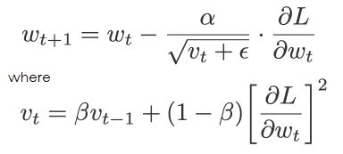

*The difference is that RMSProp calculates the **differential squared weighted average of the gradient** . This method is beneficial to eliminate the direction of large swing amplitude, and is used to correct the swing amplitude, so that the swing amplitude in each dimension is smaller. On the other hand, it also makes the network function converge faster.*

*In RMSProp learning rate gets adjusted automatically and it chooses a different learning rate for each parameter.*

*RMSProp divides the learning rate by the average of the exponential decay of squared gradients*

## *Adadelta*

*There are three problems with the Adagrad algorithm*

- *The learning rate is monotonically decreasing.*
- *The learning rate in the late training period is very small.*
- *It requires manually setting a global initial learning rate.*

*AdaDelta is an extension of AdaGrad which tends to **remove the decaying learning Rate problem** of it. Instead of accumulating all previously squared gradients, Adadelta **limits the window of accumulated past gradients** to some fixed size w. In this **exponentially moving average** is used rather than the sum of all the gradients. **Running average at time t then depends on the previous average and the current gradient**.*

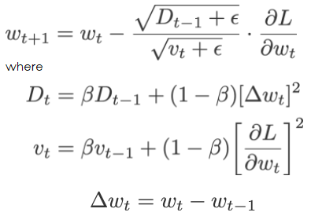

*We set γ to a similar value as the momentum term, around 0.9.*

*In Adadelta we **do not need to set the default learning rate** as we take the ratio of the running average of the previous time steps to the current gradient.*

*Advantages*

- *Now the learning rate does not decay and the training does not stop.*

*Disadvantages*

- *Computationally expensive.*

## *Adam - Adaptive Moment Estimation*

*Adaptive Moment Estimation (Adam)* *is another method that computes adaptive learning rates for each parameter. In addition to storing an exponentially decaying average of past squared gradients like Adadelta and RMSprop.*

*Adam also keeps an exponentially decaying average of past gradients, similar to momentum.*

*Adam can be viewed as a combination of Adagrad and RMSprop,(Adagrad) which works well on sparse gradients and (RMSProp) which works well in online and nonstationary settings repectively.*

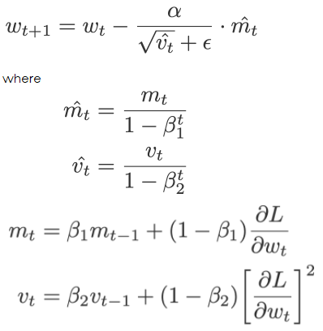

*Adam implements the **exponential moving average of the gradients** to scale the learning rate instead of a simple average as in Adagrad. It keeps an exponentially decaying average of past gradients.*

*Adam is computationally efficient and has very less memory requirement.*

*Adam optimizer is one of the most popular and famous gradient descent optimization algorithms.*

## *AdaMax*

*AdaMax is an adaptation of the Adam optimiser by the same authors using infinity norms (hence ‘max’). m is the exponential moving average of gradients, and v is the exponential moving average of past p-norm of gradients, approximated to the max function as seen below.*

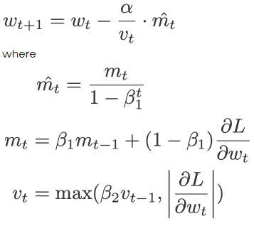

## *AMSGrad*

*Another variant of Adam is the AMSGrad. This variant revisits the adaptive learning rate component in Adam and changes it to ensure that the current v is always larger than the v from the previous time step.*

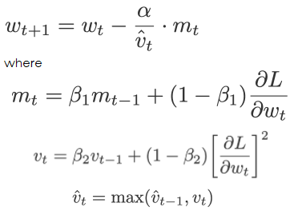

## *Comparisions*

[figure not shown]

*Figure :- SGD optimization on loss surface contours*

[figure not shown]

*Figure :- SGD optimization on saddle point*

## *How to choose optimizers?*

- *If the data is sparse, use the self-applicable methods, namely Adagrad, Adadelta, RMSprop, Adam.*
- *RMSprop, Adadelta, Adam have similar effects in many cases.*
- *Adam just added bias-correction and momentum on the basis of RMSprop.*
- *As the gradient becomes sparse, Adam will perform better than RMSprop.*

*Overall, Adam is the best choice.*

- *SGD is used in many papers, without momentum, etc. Although SGD can reach a minimum value, it takes longer than other algorithms and may be trapped in the saddle point.*
- *If faster convergence is needed, or deeper and more complex neural networks are trained, an adaptive algorithm is needed.*

*[Reference](https://towardsdatascience.com/10-gradient-descent-optimisation-algorithms-86989510b5e9)*